# Clase 10. Aplicacion Forecast de ARIMA(p, d, q) y ARMA(p, q)

Benjamin Oliva & Omar Alfaro-Rivera

02/10/2023

# Importamos Datos:

Los datos importados son:

- Pax_Nal: Pasajeros (Salidas) en vuelos nacionales
- Pax_Int: Pasajeros (Salidas) en vuelos internacionales
- Vue_Nal: Vuelos u operaciones (Salidas) en vuelos nacionales
- Vue_Int: Vuelos u operaciones (Salidas) en vuelos internacionales
- Pax_Metro: Pasajeros transportados (Millones) en el SCM
- D_Sep2017: Dummy que toma el valor de 1 en septiembre de 2017
- D_Oct2017: Dummy que toma el valor de 1 en octubre de 2017
- D_Feb2020: Dummy que toma el valor de 1 en febrero de 2020
- D_Mar2020: Dummy que toma el valor de 1 en marzo de 2020
- D_Abr2020: Dummy que toma el valor de 1 en abril de 2020
- D_May2020: Dummy que toma el valor de 1 en mayo de 2020
- D_Jun2020: Dummy que toma el valor de 1 en junio de 2020
- D_Jul2020: Dummy que toma el valor de 1 en julio de 2020
- D_Ene2021: Dummy que toma el valor de 1 en enero de 2021
- D_Mar2021: Dummy que toma el valor de 1 en marzo de 2021
- D_Ene: Dummy que toma el valor de 1 en todos los eneros
- D_Dic: Dummy que toma el valor de 1 en todos los diciembres

Fuente: INEGI, https://www.inegi.org.mx/app/indicadores/?tm=0&t=1090

```r
Datos <- read_excel("Base_Transporte_ARIMA.xlsx", sheet = "Datos", col_names = TRUE)

tail(Datos)
```

```
## # A tibble: 6 × 22
##   Periodo             Pax_Nal Pax_Int Vue_Nal Vue_Int Pax_Metro D_Sep2017
##   <dttm>                <dbl>   <dbl>   <dbl>   <dbl>     <dbl>     <dbl>
## 1 2022-12-01 00:00:00 5456045 2709516   39644   17827      90.0         0
## 2 2023-01-01 00:00:00 5058367 2533314   38226   17747      87.3         0
## 3 2023-02-01 00:00:00 4515723 2277995   33571   15756      86.7         0
## 4 2023-03-01 00:00:00 5287795 2555185   37190   17796      99.4         0
## 5 2023-04-01 00:00:00 5428414 2302621   37443   16325      86.6         0
## 6 2023-05-01 00:00:00 5351191 2161952   37841   15519      96.5         0
## # ℹ 15 more variables: D_Oct2017 <dbl>, D_Feb2020 <dbl>, D_Mar2020 <dbl>,
## #   D_Abr2020 <dbl>, D_May2020 <dbl>, D_Jun2020 <dbl>, D_Jul2020 <dbl>,
## #   D_Ene2021 <dbl>, D_Mar2021 <dbl>, D_Ene <dbl>, D_Feb <dbl>, D_Jul <dbl>,
## #   D_Dic <dbl>, D_Ene2022 <dbl>, D_Feb2022 <dbl>
```

# Conversion a series de tiempo:

```r
Pax_Nal <- ts(Datos$Pax_Nal,
              start = c(2000, 1),
              freq = 12)

LPax_Nal <- ts(log(Datos$Pax_Nal),
               start = c(2000, 1),
               freq = 12)

DLPax_Nal <- ts(log(Datos$Pax_Nal) - lag(log(Datos$Pax_Nal), 1),
                start = c(2000, 1),
                freq = 12)

D_Mar2020   <- ts(Datos$D_Mar2020,
                start = c(2000, 1),
                freq = 12)

D_Abr2020   <- ts(Datos$D_Abr2020,
                start = c(2000, 1),
                freq = 12)

D_Jun2020   <- ts(Datos$D_Jun2020,
                start = c(2000, 1),
                freq = 12)

D_Jul2020 <- ts(Datos$D_Jul2020,
                start = c(2000, 1),
                freq = 12)

D_Mar2021 <- ts(Datos$D_Mar2021,
                start = c(2000, 1),
                freq = 12)

D_Ene <- ts(Datos$D_Ene,
            start = c(2000, 1),
            freq = 12)

D_Feb <- ts(Datos$D_Feb,
            start = c(2000, 1),
            freq = 12)

D_Jul <- ts(Datos$D_Jul,
            start = c(2000, 1),
            freq = 12)

D_Dic <- ts(Datos$D_Dic,
            start = c(2000, 1),
            freq = 12)
```

# Graficas:

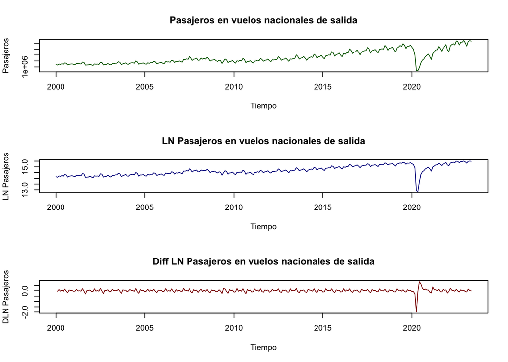

# Estimacion del proceso ARIMA(p, 1, q):

```r
ARMA_Ex_DLPax_Nal_2 <- arima(DLPax_Nal, order = c(6, 0, 6),
                             xreg = cbind(D_Ene, D_Feb, D_Jul, D_Dic, D_Mar2020, D_Abr2020, D_Jun2020, D_Jul2020, D_Mar2021),
                             method = "ML")
ARMA_Ex_DLPax_Nal_2
```

```
##
## Call:
## arima(x = DLPax_Nal, order = c(6, 0, 6), xreg = cbind(D_Ene, D_Feb, D_Jul, D_Dic,
##     D_Mar2020, D_Abr2020, D_Jun2020, D_Jul2020, D_Mar2021), method = "ML")
##
## Coefficients:
##          ar1      ar2     ar3      ar4     ar5      ar6      ma1      ma2
##       0.0026  -0.0015  0.0026  -0.0008  0.0051  -0.9971  -0.0309  -0.0621
## s.e.  0.0045   0.0049  0.0070   0.0048  0.0043   0.0024   0.0378   0.0292
##           ma3      ma4      ma5     ma6  intercept    D_Ene    D_Feb   D_Jul
##       -0.0863  -0.0025  -0.0486  0.9532     0.0203  -0.1230  -0.1696  0.1436
## s.e.   0.0325   0.0345   0.0379  0.0367     0.0040   0.1009   0.0167  0.0992
##         D_Dic  D_Mar2020  D_Abr2020  D_Jun2020  D_Jul2020  D_Mar2021
##       -0.0001    -0.4714    -1.9748     0.8921     0.4998     0.1747
## s.e.   0.0173     0.0505     0.0500     0.0526     0.0519     0.0497
##
## sigma^2 estimated as 0.002394:  log likelihood = 436.71,  aic = -827.42
```

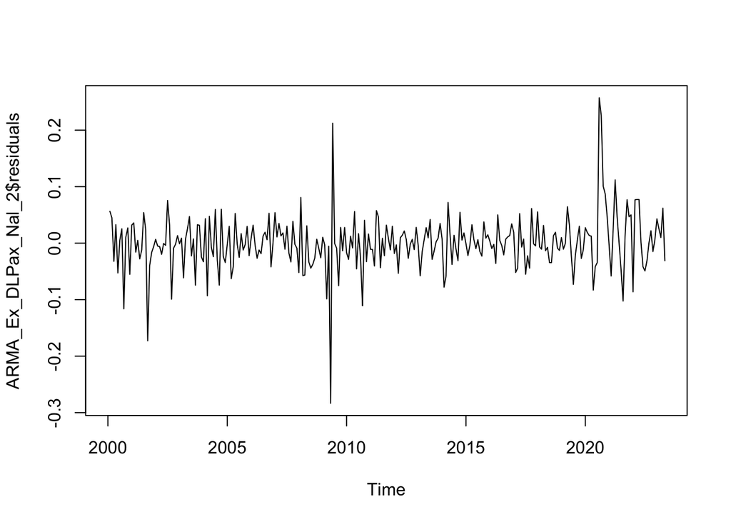

```r
plot(ARMA_Ex_DLPax_Nal_2$residuals)
```

# Forecast:

Datos Exogenos:

```r
Predict_Datos <- read_excel("Predict_Base_Transporte_ARIMA.xlsx", sheet = "Datos", col_names = TRUE)

head(Predict_Datos)
```

```
## # A tibble: 6 × 17
##   Periodo             D_Sep2017 D_Oct2017 D_Feb2020 D_Mar2020 D_Abr2020
##   <dttm>                  <dbl>     <dbl>     <dbl>     <dbl>     <dbl>
## 1 2023-06-01 00:00:00         0         0         0         0         0
## 2 2023-07-01 00:00:00         0         0         0         0         0
## 3 2023-08-01 00:00:00         0         0         0         0         0
## 4 2023-09-01 00:00:00         0         0         0         0         0
## 5 2023-10-01 00:00:00         0         0         0         0         0
## 6 2023-11-01 00:00:00         0         0         0         0         0
## # ℹ 11 more variables: D_May2020 <dbl>, D_Jun2020 <dbl>, D_Jul2020 <dbl>,
## #   D_Ene2021 <dbl>, D_Mar2021 <dbl>, D_Ene <dbl>, D_Feb <dbl>, D_Jul <dbl>,
## #   D_Dic <dbl>, D_Ene2022 <dbl>, D_Feb2022 <dbl>
```

# Conversion a series de tiempo:

```r
D_Mar2020_f <- ts(Predict_Datos$D_Mar2020,
                start = c(2023, 6),
                freq = 12)

D_Abr2020_f <- ts(Predict_Datos$D_Abr2020,
                start = c(2023, 6),
                freq = 12)

D_Jun2020_f <- ts(Predict_Datos$D_Jun2020,
                start = c(2023, 6),
                freq = 12)

D_Jul2020_f <- ts(Predict_Datos$D_Jul2020,
                start = c(2023, 6),
                freq = 12)

D_Mar2021_f <- ts(Predict_Datos$D_Mar2021,
                start = c(2023, 6),
                freq = 12)

D_Ene_f <- ts(Predict_Datos$D_Ene,
            start = c(2023, 6),
            freq = 12)

D_Feb_f <- ts(Predict_Datos$D_Feb,
            start = c(2023, 6),
            freq = 12)

D_Jul_f <- ts(Predict_Datos$D_Jul,
           start = c(2023, 6),
            freq = 12)

D_Dic_f <- ts(Predict_Datos$D_Dic,
            start = c(2023, 6),
            freq = 12)
```